# Audience Insight Analysis Of Prosper Loan Data

## by Kenneth Odoh

## Investigation Overview

In this analysis, I wanted to look at some of the features that could help predict the likeliness of a borrower to repay their debt. I focused mainly on demographic data about the debtors, such as their employment status, income range, Income verifiability status, and other factors such as total principal borrowed and loan term.

## Dataset Overview

The data consisted of 113,937 loan records, with 81 attributes on each loan entry. Some of the attributes include debtor's income status, employment status, credit grade, income range, Income verifiability status, among others.

## Distribution of Loan Statuses

Debtors with **Current** loan status make up roughly half of the entire population. They are followed by those with **Completed** loan status.

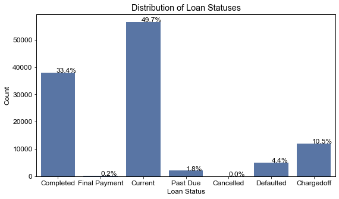

## Distribution of Listing Categories

Debtors were unevenly distributed across different categories. More than half of all debtors borrow to offset other debts. When plotted on a logarithimic scale and sorted in descending order, the distribution of listing categories forms steep slopes.

The majority of the debtors borrow to **spend**, not **invest**. Only 6% of them borrow for business purposes.

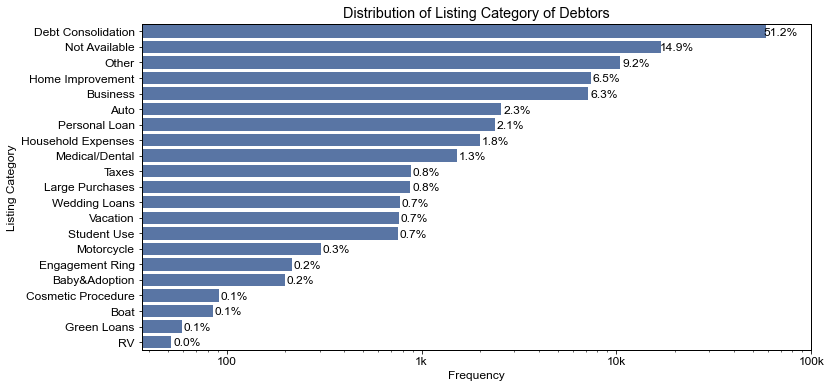

## Distribution of Principal Borrowed

Principal Borrowed has a long tail distribution. On a logarithimic scale, it forms uniformly distributed spikes.  
The distribution clusters towards the left.

This indicates that the majority of debtors borrow at the lower ranges of less than \$10, 000.

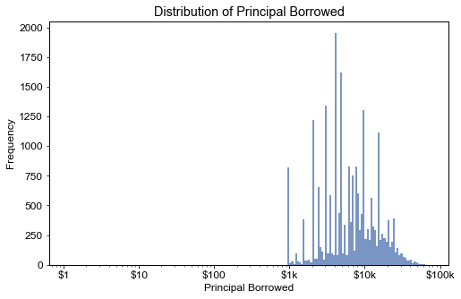

## Distribution of Employment Status

87% of debtors are at least, **Employed**. Even though debtors largely borrow to spend, it is a sign of hope since the majority of them have an established source of income.

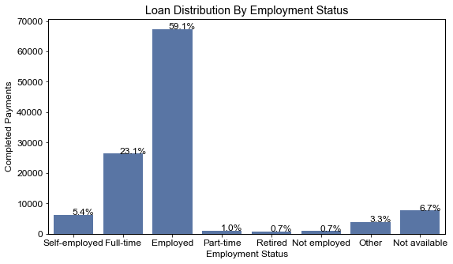

## Distribution of Loan by Income Range

About 85% of borrowers have at least, $25k as income. More than half of the debtors are middle class income earners.

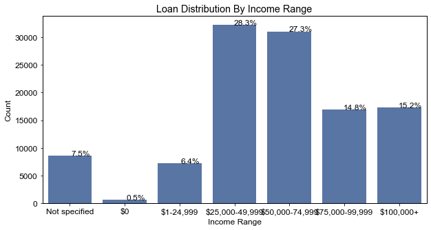

## Effect of Employment Status on Loan Status

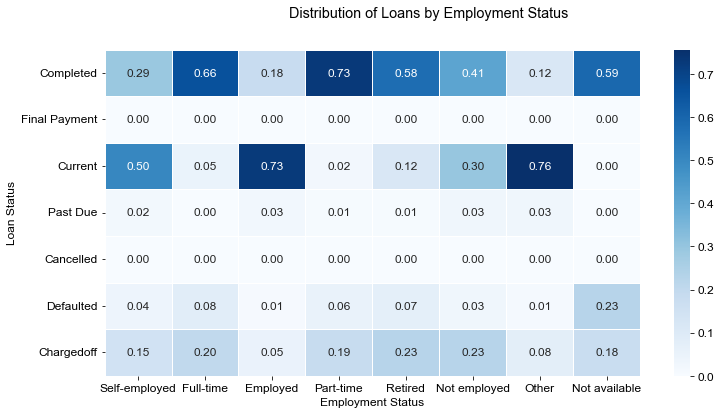

## Effect of Principal Borrowed on Loan Status

Low-range borrowers show the higher loan repayment rate than high-range borrowers. However, bad debt incurement is also higher with low principal borrowers.

It seems like lenders are more likely to write off smaller loans.

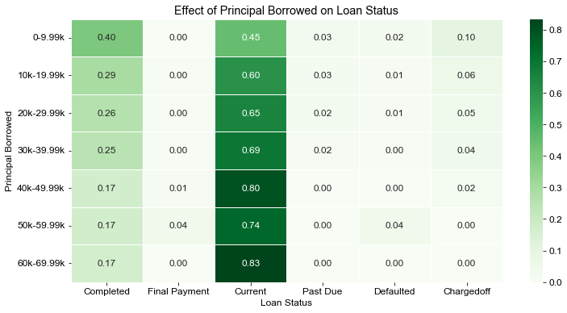

## More on The Twin Effect of Loan Amount on Loan Status

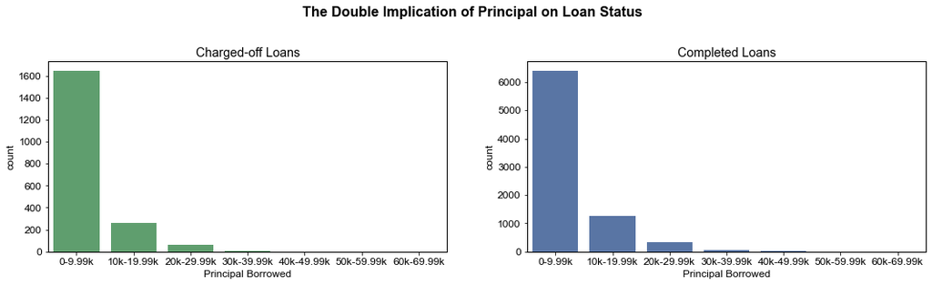

## Having a Source of Income Can Motivate One to Borrow Higher

Employed debtors (Self-employed, Employed, Full-time) borrow the highest amounts. This is quite understandable. Having a source of income gives higher confidence for anyone wanting to take a loan. Perhaps, a good number of them (especially the self-employed) are using it for business purposes. Others who are not into business, borrow to foot bills, and hope to repay once they get paid their salaries.

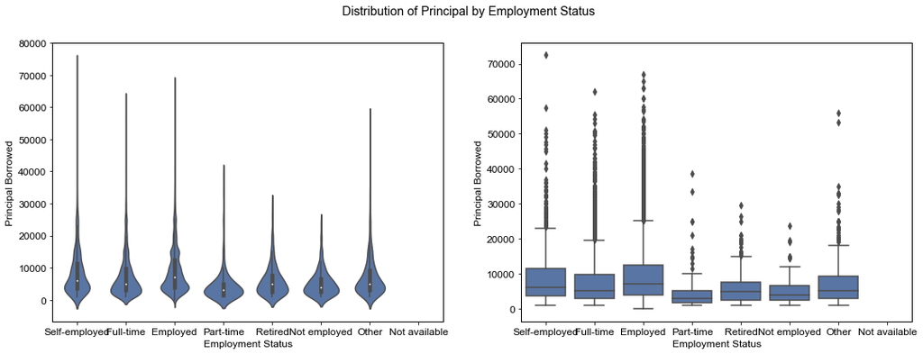

## Combined Effect Of Employment Status and Income Verifiability on Loan Status

Most completed payments were done by debtors who have verifiable sources of income.

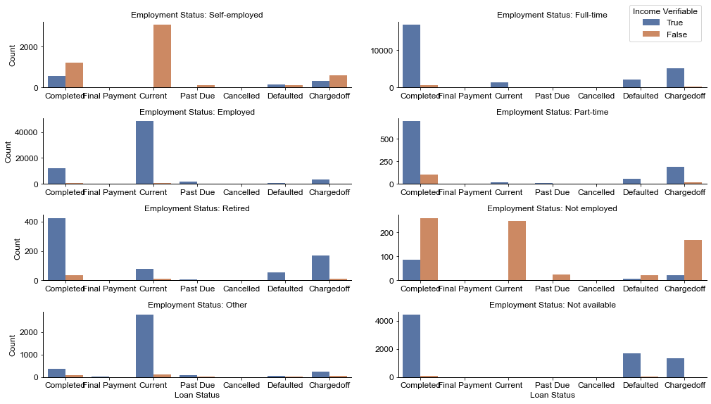